# Ejemplo Vec e6

WILSON SANDOVAL

2025-05-10

## Datos alemanes de tasa de interés e inflación

El conjunto de datos contiene series temporales trimestrales no ajustadas estacionalmente para las tasas de interés e inflación alemanas a largo plazo desde 1972Q2 hasta 1998Q4. Fue producido a partir del archivo E6 de los conjuntos de datos asociados con Lütkepohl (2007). Los datos sin procesar están disponibles en http://www.jmulti.de/download/datasets/e6.dat y se obtuvieron originalmente de Deutsche Bundesbank y Deutsches Institut für Wirtschaftsforschung

## Cargar las librerias

```r
library(vars)
library(tseries)
library(forecast)
library(urca)
library(highcharter)
library(bvartools)
library(MTS)
```

## Cargar la base datos y graficarla

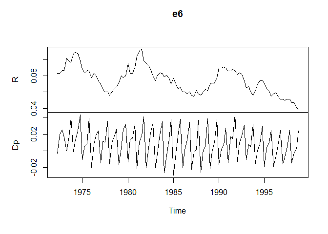

```r
data("e6")
plot(e6)
```

```r
hchart(e6)%>%hc_add_theme(hc_theme_economist())
```

[interactive chart not shown]

```r
summary(e6)
```

```
##        R                 Dp
##  Min.   :0.03800   Min.   :-0.029195
##  1st Qu.:0.06050   1st Qu.:-0.004265
##  Median :0.07400   Median : 0.008706
##  Mean   :0.07458   Mean   : 0.008397
##  3rd Qu.:0.08600   3rd Qu.: 0.023910
##  Max.   :0.11300   Max.   : 0.043004
```

- R:=tasa de interés nominal a largo plazo
- Dp:= Δ log del deflactor del PIB. es un índice de precios que calcula la variación de los precios de una economía en un periodo determinado utilizando para ello el producto interior bruto (PIB).

El deflactor del PIB se utiliza para conocer la parte del crecimiento de una economía que se debe al aumento de precios.

## Pruebas de estacionariedad

- pruebas de estacionariedad R tasa de interes nominal

```r
adf.R<- ur.df(e6[,1], type = "trend", selectlags = "BIC")
summary(adf.R)
```

```
##
## ###############################################
## # Augmented Dickey-Fuller Test Unit Root Test #
## ###############################################
##
## Test regression trend
##
##
## Call:
## lm(formula = z.diff ~ z.lag.1 + 1 + tt + z.diff.lag)
##
## Residuals:
##        Min         1Q     Median         3Q        Max
## -0.0136682 -0.0038094 -0.0001308  0.0031834  0.0144628
##
## Coefficients:
##               Estimate Std. Error t value Pr(>|t|)
## (Intercept)  9.248e-03  3.905e-03   2.368   0.0198 *
## z.lag.1     -9.742e-02  4.108e-02  -2.372   0.0196 *
## tt          -4.266e-05  2.141e-05  -1.993   0.0490 *
## z.diff.lag   2.027e-01  9.835e-02   2.061   0.0419 *
## ---
## Signif. codes:  0 '***' 0.001 '**' 0.01 '*' 0.05 '.' 0.1 ' ' 1
##
## Residual standard error: 0.005404 on 101 degrees of freedom
## Multiple R-squared:  0.0806, Adjusted R-squared:  0.05329
## F-statistic: 2.951 on 3 and 101 DF,  p-value: 0.03625
##
##
## Value of test-statistic is: -2.3716 2.2271 3.1006
##
## Critical values for test statistics:
##       1pct  5pct 10pct
## tau3 -3.99 -3.43 -3.13
## phi2  6.22  4.75  4.07
## phi3  8.43  6.49  5.47
```

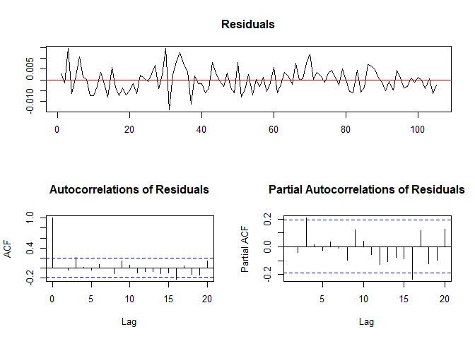

```r
plot(adf.R)
```

```r
adf.test(e6[,1])
```

```
##
##  Augmented Dickey-Fuller Test
##
## data:  e6[, 1]
## Dickey-Fuller = -2.7095, Lag order = 4, p-value = 0.2824
## alternative hypothesis: stationary
```

```r
pp.test(e6[,1])
```

```
##
##  Phillips-Perron Unit Root Test
##
## data:  e6[, 1]
## Dickey-Fuller Z(alpha) = -12.217, Truncation lag parameter = 4, p-value
## = 0.4079
## alternative hypothesis: stationary
```

- pruebas de estacionariedad Dp

```r
adf.Dp <- ur.df(e6[,2], type = "trend", selectlags = "BIC")
summary(adf.Dp)
```

```
##
## ###############################################
## # Augmented Dickey-Fuller Test Unit Root Test #
## ###############################################
##
## Test regression trend
##
##
## Call:
## lm(formula = z.diff ~ z.lag.1 + 1 + tt + z.diff.lag)
##
## Residuals:
##       Min        1Q    Median        3Q       Max
## -0.024165 -0.012291 -0.005201  0.012061  0.044861
##
## Coefficients:
##               Estimate Std. Error t value Pr(>|t|)
## (Intercept)  2.470e-02  3.820e-03   6.467 3.61e-09 ***
## z.lag.1     -1.846e+00  1.437e-01 -12.853  < 2e-16 ***
## tt          -1.712e-04  5.481e-05  -3.123  0.00234 **
## z.diff.lag   4.412e-01  8.956e-02   4.926 3.29e-06 ***
## ---
## Signif. codes:  0 '***' 0.001 '**' 0.01 '*' 0.05 '.' 0.1 ' ' 1
##
## Residual standard error: 0.01645 on 101 degrees of freedom
## Multiple R-squared:  0.7078, Adjusted R-squared:  0.6991
## F-statistic: 81.56 on 3 and 101 DF,  p-value: < 2.2e-16
##
##
## Value of test-statistic is: -12.8528 55.0768 82.6141
##
## Critical values for test statistics:
##       1pct  5pct 10pct
## tau3 -3.99 -3.43 -3.13
## phi2  6.22  4.75  4.07
## phi3  8.43  6.49  5.47
```

```r
adf.test(e6[,2])
```

```
##
##  Augmented Dickey-Fuller Test
##
## data:  e6[, 2]
## Dickey-Fuller = -2.5209, Lag order = 4, p-value = 0.3606
## alternative hypothesis: stationary
```

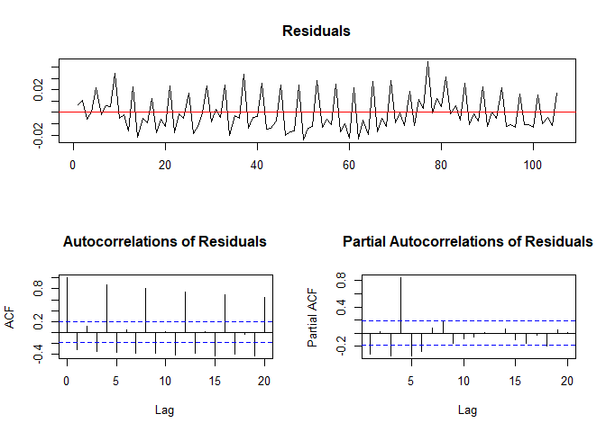

```r
plot(adf.Dp)
```

```r
pp.test(e6[,2])
```

```
##
##  Phillips-Perron Unit Root Test
##
## data:  e6[, 2]
## Dickey-Fuller Z(alpha) = -106.58, Truncation lag parameter = 4, p-value
## = 0.01
## alternative hypothesis: stationary
```

## Pruebas con una diferencia

Con una diferencia

- R

```r
diff.adf.R <- ur.df(diff(e6[,1]), type = "trend", selectlags = "BIC")
summary(diff.adf.R)
```

```
##
## ###############################################
## # Augmented Dickey-Fuller Test Unit Root Test #
## ###############################################
##
## Test regression trend
##
##
## Call:
## lm(formula = z.diff ~ z.lag.1 + 1 + tt + z.diff.lag)
##
## Residuals:
##        Min         1Q     Median         3Q        Max
## -0.0141027 -0.0039508 -0.0004519  0.0029505  0.0150488
##
## Coefficients:
##               Estimate Std. Error t value Pr(>|t|)
## (Intercept)  1.996e-04  1.115e-03   0.179    0.858
## z.lag.1     -8.952e-01  1.304e-01  -6.867 5.63e-10 ***
## tt          -1.169e-05  1.824e-05  -0.641    0.523
## z.diff.lag   5.332e-02  1.000e-01   0.533    0.595
## ---
## Signif. codes:  0 '***' 0.001 '**' 0.01 '*' 0.05 '.' 0.1 ' ' 1
##
## Residual standard error: 0.005559 on 100 degrees of freedom
## Multiple R-squared:  0.4273, Adjusted R-squared:  0.4101
## F-statistic: 24.87 on 3 and 100 DF,  p-value: 4.19e-12
##
##
## Value of test-statistic is: -6.867 15.7276 23.5778
##
## Critical values for test statistics:
##       1pct  5pct 10pct
## tau3 -3.99 -3.43 -3.13
## phi2  6.22  4.75  4.07
## phi3  8.43  6.49  5.47
```

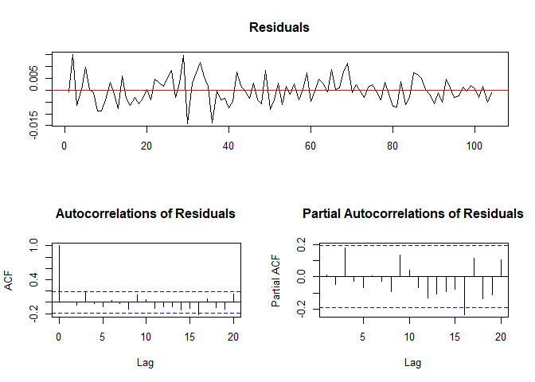

```r
plot(diff.adf.R)
```

- Dp

```r
diff.adf.Dp <- ur.df(diff(e6[,2]), type = "trend", selectlags = "BIC")
summary(diff.adf.Dp)
```

```
##
## ###############################################
## # Augmented Dickey-Fuller Test Unit Root Test #
## ###############################################
##
## Test regression trend
##
##
## Call:
## lm(formula = z.diff ~ z.lag.1 + 1 + tt + z.diff.lag)
##
## Residuals:
##       Min        1Q    Median        3Q       Max
## -0.044322 -0.014729 -0.000134  0.021484  0.045162
##
## Coefficients:
##               Estimate Std. Error t value Pr(>|t|)
## (Intercept) -9.275e-04  5.034e-03  -0.184 0.854205
## z.lag.1     -1.998e+00  1.615e-01 -12.367  < 2e-16 ***
## tt           1.533e-05  8.206e-05   0.187 0.852215
## z.diff.lag   3.469e-01  9.372e-02   3.701 0.000351 ***
## ---
## Signif. codes:  0 '***' 0.001 '**' 0.01 '*' 0.05 '.' 0.1 ' ' 1
##
## Residual standard error: 0.02512 on 100 degrees of freedom
## Multiple R-squared:  0.7719, Adjusted R-squared:  0.765
## F-statistic: 112.8 on 3 and 100 DF,  p-value: < 2.2e-16
##
##
## Value of test-statistic is: -12.3671 51.0126 76.5188
##
## Critical values for test statistics:
##       1pct  5pct 10pct
## tau3 -3.99 -3.43 -3.13
## phi2  6.22  4.75  4.07
## phi3  8.43  6.49  5.47
```

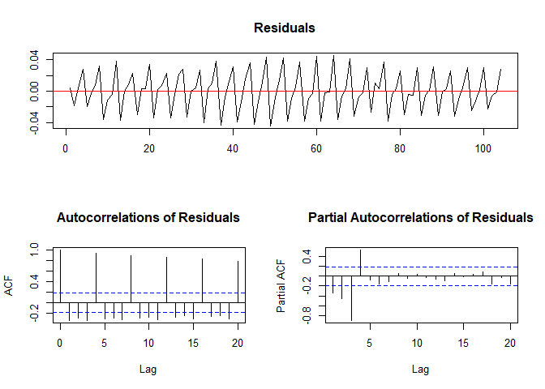

```r
plot(diff.adf.Dp)
```

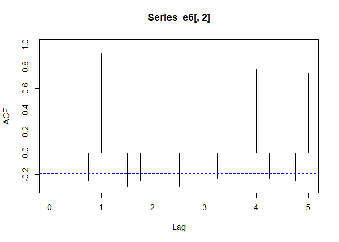

```r
acf(e6[,2])
```

```r
adf.test(diff(e6[,1]))
```

```
##
##  Augmented Dickey-Fuller Test
##
## data:  diff(e6[, 1])
## Dickey-Fuller = -4.2398, Lag order = 4, p-value = 0.01
## alternative hypothesis: stationary
```

```r
adf.test(diff(e6[,2]))
```

```
##
##  Augmented Dickey-Fuller Test
##
## data:  diff(e6[, 2])
## Dickey-Fuller = -6.2017, Lag order = 4, p-value = 0.01
## alternative hypothesis: stationary
```

```r
pp.test(diff(e6[,1]))
```

```
##
##  Phillips-Perron Unit Root Test
##
## data:  diff(e6[, 1])
## Dickey-Fuller Z(alpha) = -91.522, Truncation lag parameter = 4, p-value
## = 0.01
## alternative hypothesis: stationary
```

```r
pp.test(diff(e6[,2]))
```

```
##
##  Phillips-Perron Unit Root Test
##
## data:  diff(e6[, 2])
## Dickey-Fuller Z(alpha) = -123.47, Truncation lag parameter = 4, p-value
## = 0.01
## alternative hypothesis: stationary
```

## Una vez las series son estacionarias, se procede a realiza la estimacion

```r
var_aic <- VARselect(e6,lag.max=10, type = "both")
VARselect(e6)
```

```
## $selection
## AIC(n)  HQ(n)  SC(n) FPE(n)
##      4      4      4      4
##
## $criteria
##                    1             2             3             4             5
## AIC(n) -1.841669e+01 -1.861079e+01 -1.955586e+01 -2.063736e+01 -2.056539e+01
## HQ(n)  -1.835229e+01 -1.850346e+01 -1.940560e+01 -2.044417e+01 -2.032927e+01
## SC(n)  -1.825743e+01 -1.834536e+01 -1.918425e+01 -2.015958e+01 -1.998144e+01
## FPE(n)  1.004041e-08  8.270206e-09  3.215267e-09  1.090873e-09  1.173312e-09
##                    6             7             8             9            10
## AIC(n) -2.053910e+01 -2.051298e+01 -2.051770e+01 -2.046229e+01 -2.046025e+01
## HQ(n)  -2.026005e+01 -2.019100e+01 -2.015279e+01 -2.005444e+01 -2.000947e+01
## SC(n)  -1.984897e+01 -1.971668e+01 -1.961523e+01 -1.945364e+01 -1.934543e+01
## FPE(n)  1.206122e-09  1.240214e-09  1.237229e-09  1.311578e-09  1.319081e-09
```

```r
var_aic
```

```
## $selection
## AIC(n)  HQ(n)  SC(n) FPE(n)
##      4      4      4      4
##
## $criteria
##                    1             2             3             4             5
## AIC(n) -1.839053e+01 -1.859842e+01 -1.964035e+01 -2.062024e+01 -2.054757e+01
## HQ(n)  -1.830467e+01 -1.846962e+01 -1.946862e+01 -2.040558e+01 -2.028998e+01
## SC(n)  -1.817819e+01 -1.827990e+01 -1.921565e+01 -2.008937e+01 -1.991052e+01
## FPE(n)  1.030704e-08  8.374267e-09  2.955499e-09  1.110156e-09  1.195122e-09
##                    6             7             8             9            10
## AIC(n) -2.052637e+01 -2.051713e+01 -2.050813e+01 -2.046156e+01 -2.047710e+01
## HQ(n)  -2.022585e+01 -2.017368e+01 -2.012175e+01 -2.003225e+01 -2.000485e+01
## SC(n)  -1.978315e+01 -1.966774e+01 -1.955257e+01 -1.939982e+01 -1.930919e+01
## FPE(n)  1.222572e-09  1.236418e-09  1.250869e-09  1.314820e-09  1.299817e-09
```

Según el AIC, FPE, SC, HQ, el número de retraso óptimo es $p = 4$,

```r
VARorder(e6, maxp=10)
```

```
## selected order: aic =  4
## selected order: bic =  4
## selected order: hq =  4
## Summary table:
##        p      AIC      BIC       HQ     M(p) p-value
##  [1,]  0 -16.2725 -16.2725 -16.2725   0.0000  0.0000
##  [2,]  1 -18.4656 -18.3657 -18.4251 212.0517  0.0000
##  [3,]  2 -18.6674 -18.4676 -18.5864  25.3067  0.0000
##  [4,]  3 -19.6202 -19.3205 -19.4987  91.9651  0.0000
##  [5,]  4 -20.7094 -20.3098 -20.5474 101.8477  0.0000
##  [6,]  5 -20.6452 -20.1456 -20.4426   0.8987  0.9248
##  [7,]  6 -20.6266 -20.0271 -20.3835   4.6910  0.3205
##  [8,]  7 -20.6082 -19.9087 -20.3246   4.5932  0.3316
##  [9,]  8 -20.6206 -19.8213 -20.2966   6.9320  0.1395
## [10,]  9 -20.5729 -19.6736 -20.2083   2.0973  0.7179
## [11,] 10 -20.5786 -19.5794 -20.1735   6.0729  0.1938
```

## VAR(4)

```r
p1ct <- vars::VAR(e6, p = 4, type = "both")
p1ct
```

```
##
## VAR Estimation Results:
## =======================
##
## Estimated coefficients for equation R:
## ======================================
## Call:
## R = R.l1 + Dp.l1 + R.l2 + Dp.l2 + R.l3 + Dp.l3 + R.l4 + Dp.l4 + const + trend
##
##          R.l1         Dp.l1          R.l2         Dp.l2          R.l3
##  1.099030e+00  4.741335e-02 -2.277632e-01  6.742609e-02  2.234283e-01
##         Dp.l3          R.l4         Dp.l4         const         trend
##  7.871929e-02 -2.518795e-01  1.770827e-02  1.173696e-02 -3.632482e-05
##
##
## Estimated coefficients for equation Dp:
## =======================================
## Call:
## Dp = R.l1 + Dp.l1 + R.l2 + Dp.l2 + R.l3 + Dp.l3 + R.l4 + Dp.l4 + const + trend
##
##          R.l1         Dp.l1          R.l2         Dp.l2          R.l3
##  1.883463e-01 -1.993946e-01  8.394473e-02 -1.829431e-01 -1.585265e-01
##         Dp.l3          R.l4         Dp.l4         const         trend
## -1.898380e-01  2.658589e-02  7.603442e-01 -2.454637e-03 -2.859212e-05
```

```r
summary(p1ct, equation = "R")
```

```
##
## VAR Estimation Results:
## =========================
## Endogenous variables: R, Dp
## Deterministic variables: both
## Sample size: 103
## Log Likelihood: 780.741
## Roots of the characteristic polynomial:
## 0.9902 0.9882 0.9882 0.8398 0.8096 0.8096 0.6006 0.6006
## Call:
## vars::VAR(y = e6, p = 4, type = "both")
##
##
## Estimation results for equation R:
## ==================================
## R = R.l1 + Dp.l1 + R.l2 + Dp.l2 + R.l3 + Dp.l3 + R.l4 + Dp.l4 + const + trend
##
##         Estimate Std. Error t value Pr(>|t|)
## R.l1   1.099e+00  1.007e-01  10.913  < 2e-16 ***
## Dp.l1  4.741e-02  5.656e-02   0.838  0.40406
## R.l2  -2.278e-01  1.517e-01  -1.502  0.13653
## Dp.l2  6.743e-02  5.695e-02   1.184  0.23949
## R.l3   2.234e-01  1.518e-01   1.472  0.14450
## Dp.l3  7.872e-02  5.670e-02   1.388  0.16833
## R.l4  -2.519e-01  1.031e-01  -2.443  0.01647 *
## Dp.l4  1.771e-02  5.612e-02   0.316  0.75306
## const  1.174e-02  4.157e-03   2.824  0.00581 **
## trend -3.632e-05  2.418e-05  -1.502  0.13639
## ---
## Signif. codes:  0 '***' 0.001 '**' 0.01 '*' 0.05 '.' 0.1 ' ' 1
##
##
## Residual standard error: 0.005337 on 93 degrees of freedom
## Multiple R-Squared: 0.9068,  Adjusted R-squared: 0.8978
## F-statistic: 100.5 on 9 and 93 DF,  p-value: < 2.2e-16
##
##
##
## Covariance matrix of residuals:
##             R        Dp
## R   2.849e-05 -3.02e-06
## Dp -3.020e-06  3.88e-05
##
## Correlation matrix of residuals:
##           R       Dp
## R   1.00000 -0.09086
## Dp -0.09086  1.00000
```

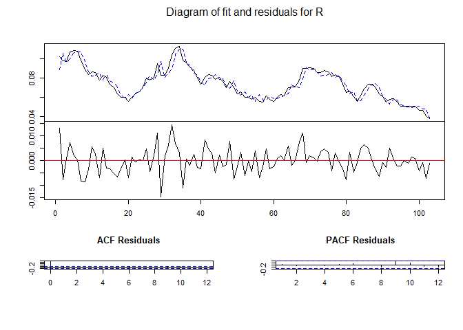

```r
plot(p1ct, names = "R")
```

```r
summary(p1ct, equation = "Dp")
```

```
##
## VAR Estimation Results:
## =========================
## Endogenous variables: R, Dp
## Deterministic variables: both
## Sample size: 103
## Log Likelihood: 780.741
## Roots of the characteristic polynomial:
## 0.9902 0.9882 0.9882 0.8398 0.8096 0.8096 0.6006 0.6006
## Call:
## vars::VAR(y = e6, p = 4, type = "both")
##
##
## Estimation results for equation Dp:
## ===================================
## Dp = R.l1 + Dp.l1 + R.l2 + Dp.l2 + R.l3 + Dp.l3 + R.l4 + Dp.l4 + const + trend
##
##         Estimate Std. Error t value Pr(>|t|)
## R.l1   1.883e-01  1.175e-01   1.603  0.11241
## Dp.l1 -1.994e-01  6.601e-02  -3.021  0.00326 **
## R.l2   8.394e-02  1.770e-01   0.474  0.63640
## Dp.l2 -1.829e-01  6.647e-02  -2.752  0.00711 **
## R.l3  -1.585e-01  1.772e-01  -0.895  0.37325
## Dp.l3 -1.898e-01  6.617e-02  -2.869  0.00509 **
## R.l4   2.659e-02  1.203e-01   0.221  0.82563
## Dp.l4  7.603e-01  6.549e-02  11.609  < 2e-16 ***
## const -2.455e-03  4.851e-03  -0.506  0.61403
## trend -2.859e-05  2.822e-05  -1.013  0.31354
## ---
## Signif. codes:  0 '***' 0.001 '**' 0.01 '*' 0.05 '.' 0.1 ' ' 1
##
##
## Residual standard error: 0.006229 on 93 degrees of freedom
## Multiple R-Squared: 0.903,   Adjusted R-squared: 0.8936
## F-statistic: 96.17 on 9 and 93 DF,  p-value: < 2.2e-16
##
##
##
## Covariance matrix of residuals:
##             R        Dp
## R   2.849e-05 -3.02e-06
## Dp -3.020e-06  3.88e-05
##
## Correlation matrix of residuals:
##           R       Dp
## R   1.00000 -0.09086
## Dp -0.09086  1.00000
```

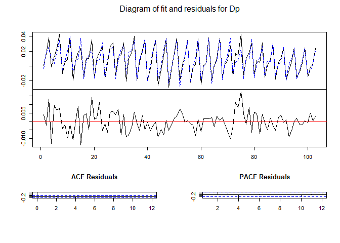

```r
plot(p1ct , name="Dp")
```

## Diagnostico VAR(4)

```r
ser11 <- serial.test(p1ct, lags.pt =4, type = "PT.asymptotic")
ser11$serial
```

```
##
##  Portmanteau Test (asymptotic)
##
## data:  Residuals of VAR object p1ct
## Chi-squared = 11.289, df = 0, p-value < 2.2e-16
```

```r
norm1 <-normality.test(p1ct)
norm1$jb.mul
```

```
## $JB
##
##  JB-Test (multivariate)
##
## data:  Residuals of VAR object p1ct
## Chi-squared = 2.2792, df = 4, p-value = 0.6846
##
##
## $Skewness
##
##  Skewness only (multivariate)
##
## data:  Residuals of VAR object p1ct
## Chi-squared = 1.43, df = 2, p-value = 0.4892
##
##
## $Kurtosis
##
##  Kurtosis only (multivariate)
##
## data:  Residuals of VAR object p1ct
## Chi-squared = 0.84915, df = 2, p-value = 0.654
```

```r
arch1 <- arch.test(p1ct, lags.multi = 12)
arch1$arch.mul
```

```
##
##  ARCH (multivariate)
##
## data:  Residuals of VAR object p1ct
## Chi-squared = 140.71, df = 108, p-value = 0.01885
```

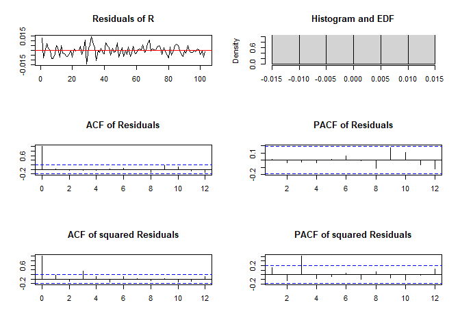

```r
plot(arch1, names = "R")
```

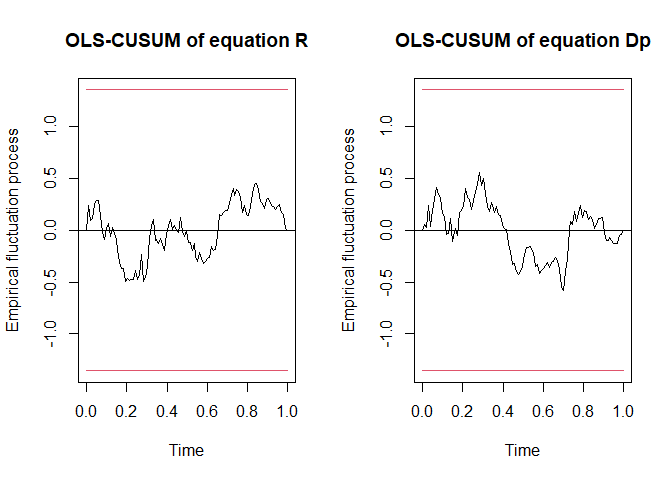

```r
plot(stability(p1ct), nc = 2)
```

## Estimar prueba Johanssen cointegracion.

```r
vec <- ca.jo(e6, ecdet = "none", type = "eigen",
             K = 4, spec = "transitory", season = 4)

summary(vec)
```

```
##
## ######################
## # Johansen-Procedure #
## ######################
##
## Test type: maximal eigenvalue statistic (lambda max) , with linear trend
##
## Eigenvalues (lambda):
## [1] 0.15184737 0.03652339
##
## Values of teststatistic and critical values of test:
##
##           test 10pct  5pct  1pct
## r <= 1 |  3.83  6.50  8.18 11.65
## r = 0  | 16.96 12.91 14.90 19.19
##
## Eigenvectors, normalised to first column:
## (These are the cointegration relations)
##
##            R.l1    Dp.l1
## R.l1   1.000000 1.000000
## Dp.l1 -3.961937 1.700513
##
## Weights W:
## (This is the loading matrix)
##
##            R.l1       Dp.l1
## R.d  -0.1028717 -0.03938511
## Dp.d  0.1577005 -0.02146119
```

```r
class(vec)
```

```
## [1] "ca.jo"
## attr(,"package")
## [1] "urca"
```

En la salida anterior, se rechaza la hipótesis nula de no cointegración y no rechazamos la hipótesis nula de a lo sumo una ecuación de cointegración. Por lo tanto concluimos que hay una ecuación de cointegración en el modelo bivariado.

## Transformar VEC a VAR con r = 1

```r
var <- vec2var(vec, r = 1)
var
```

```
##
## Coefficient matrix of lagged endogenous variables:
##
## A1:
##         R.l1      Dp.l1
## R  1.1658999 0.19732143
## Dp 0.2230793 0.03598872
##
##
## A2:
##           R.l2       Dp.l2
## R  -0.28658151 -0.01273115
## Dp -0.06967063 -0.05162046
##
##
## A3:
##          R.l3      Dp.l3
## R  0.24061842 0.11535798
## Dp 0.02269341 0.04361369
##
##
## A4:
##           R.l4     Dp.l4
## R  -0.22280852 0.1076232
## Dp -0.01840163 0.3472186
##
##
## Coefficient matrix of deterministic regressor(s).
##
##        constant         sd1          sd2          sd3
## R   0.003982491 0.007367097 -0.001898661 -0.001485568
## Dp -0.006961569 0.016214946  0.017688578  0.034124804
```

```r
class(var)
```

```
## [1] "vec2var"
```

```r
var1<-cajorls(vec, r=1)
var1
```

```
## $rlm
##
## Call:
## lm(formula = substitute(form1), data = data.mat)
##
## Coefficients:
##           R.d        Dp.d
## ect1      -0.102872   0.157700
## constant   0.003982  -0.006962
## sd1        0.007367   0.016215
## sd2       -0.001899   0.017689
## sd3       -0.001486   0.034125
## R.dl1      0.268772   0.065379
## Dp.dl1    -0.210250  -0.339212
## R.dl2     -0.017810  -0.004292
## Dp.dl2    -0.222981  -0.390832
## R.dl3      0.222809   0.018402
## Dp.dl3    -0.107623  -0.347219
##
##
## $beta
##            ect1
## R.l1   1.000000
## Dp.l1 -3.961937
```

# Validacion

### Correlación serial

$H_0: \text{Ausencia de correlación serial en los residuales}$

```r
ser11 <- serial.test(var, lags.pt = 5, type = "PT.asymptotic")
ser11$serial
```

```
##
##  Portmanteau Test (asymptotic)
##
## data:  Residuals of VAR object var
## Chi-squared = 4.8421, df = 6, p-value = 0.5642
```

### Normalidad de los residuales

$H_0 : \text{Los residuales siguen una distribución normal}$

```r
norm1 <-normality.test(var)
norm1$jb.mul
```

```
## $JB
##
##  JB-Test (multivariate)
##
## data:  Residuals of VAR object var
## Chi-squared = 2.5413, df = 4, p-value = 0.6373
##
##
## $Skewness
##
##  Skewness only (multivariate)
##
## data:  Residuals of VAR object var
## Chi-squared = 0.21828, df = 2, p-value = 0.8966
##
##
## $Kurtosis
##
##  Kurtosis only (multivariate)
##
## data:  Residuals of VAR object var
## Chi-squared = 2.323, df = 2, p-value = 0.313
```

### Homocedasticiad

$H_0 : \text{Los residuales son homocedasticos}$

```r
arch1 <- arch.test(var, lags.multi = 7)
arch1$arch.mul
```

```
##
##  ARCH (multivariate)
##
## data:  Residuals of VAR object var
## Chi-squared = 100.43, df = 63, p-value = 0.001901
```

```r
summary(arch1)
```

```
##          Length Class  Mode
## resid    206    -none- numeric
## arch.mul   5    htest  list
```

```r
class(arch1)
```

```
## [1] "varcheck"
```

```r
arch1$resid
```

[output not shown]

[output cut: 89 more lines]

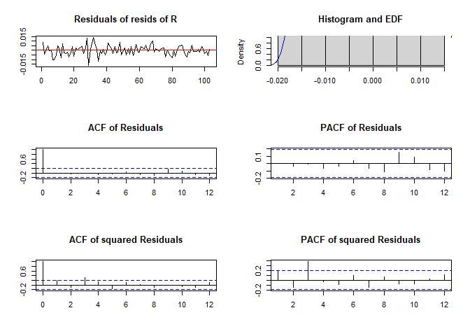

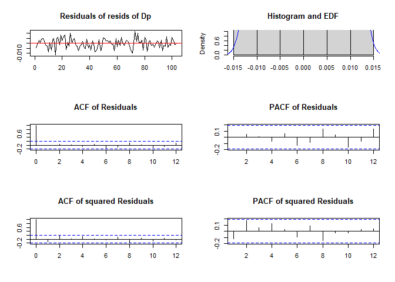

```r
plot(arch1)
```

```r
#plot(vars::stability(var), nc = 2)
```

## La función de respuesta al impulso se calcula de la manera habitual utilizando la función irf.

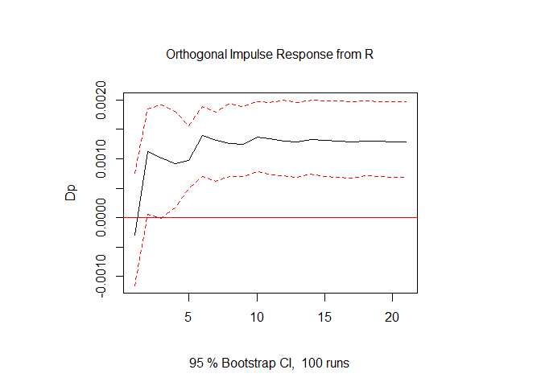

```r
ir <- vars::irf(var, n.ahead = 20, impulse = "R", response = "Dp")

plot(ir)
```

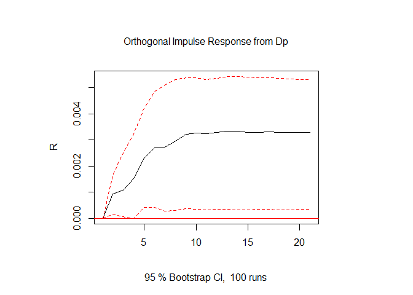

```r
ir1 <- vars::irf(var, n.ahead = 20, impulse = "Dp", response = "R")

plot(ir1)
```

## Descomposición de la varianza FEVD

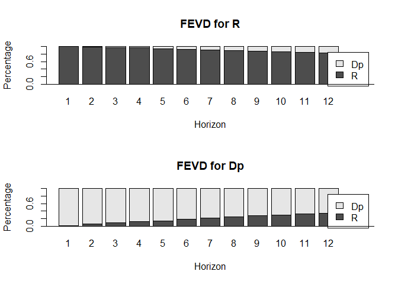

```r
fevd.R <- vars::fevd(var, n.ahead = 12)
plot(fevd.R)
```

## Pronóstico

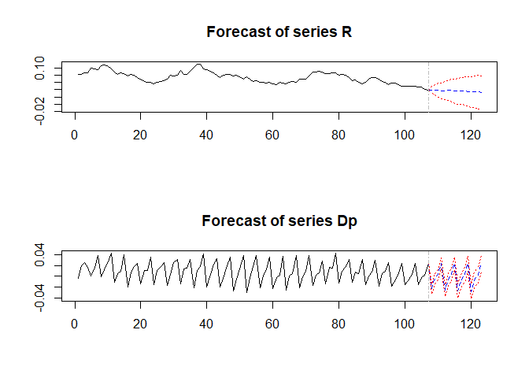

```r
predictions <- predict(var, n.ahead = 16, ci = 0.95)
plot(predictions)
```

```r
rt=e6[,1] -3.9619*e6[,2]
```

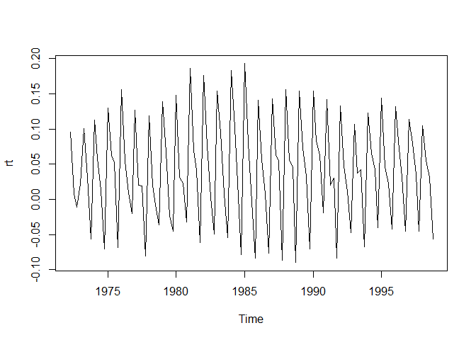

```r
plot(rt)
```

```r
adf.test(rt)
```

```
##
##  Augmented Dickey-Fuller Test
##
## data:  rt
## Dickey-Fuller = -2.9879, Lag order = 4, p-value = 0.1669
## alternative hypothesis: stationary
```

```r
pp.test(rt)
```

```
##
##  Phillips-Perron Unit Root Test
##
## data:  rt
## Dickey-Fuller Z(alpha) = -105.3, Truncation lag parameter = 4, p-value
## = 0.01
## alternative hypothesis: stationary
```

```r
summary(ur.df(rt))
```

```
##
## ###############################################
## # Augmented Dickey-Fuller Test Unit Root Test #
## ###############################################
##
## Test regression none
##
##
## Call:
## lm(formula = z.diff ~ z.lag.1 - 1 + z.diff.lag)
##
## Residuals:
##      Min       1Q   Median       3Q      Max
## -0.09005 -0.01904  0.04231  0.09689  0.19470
##
## Coefficients:
##            Estimate Std. Error t value Pr(>|t|)
## z.lag.1    -0.99203    0.13754  -7.213 9.54e-11 ***
## z.diff.lag  0.01369    0.09821   0.139    0.889
## ---
## Signif. codes:  0 '***' 0.001 '**' 0.01 '*' 0.05 '.' 0.1 ' ' 1
##
## Residual standard error: 0.08586 on 103 degrees of freedom
## Multiple R-squared:  0.4884, Adjusted R-squared:  0.4785
## F-statistic: 49.16 on 2 and 103 DF,  p-value: 1.024e-15
##
##
## Value of test-statistic is: -7.2126
##
## Critical values for test statistics:
##       1pct  5pct 10pct
## tau1 -2.58 -1.95 -1.62
```